# Preparación de los datos

# Breve introducción a ggpairs

`ggpairs()` es una función de la librería GGally que permite crear matrices de gráficos y es realmente útil en la etapa de análisis y exploración de los datos. Pueden encontrar más información sobre `ggpairs()` y GGally en el siguiente enlace https://ggobi.github.io/ggally/#ggally

El siguiente ejemplo muestra el gráfico de las correlaciones y densidades de algunos atributos del dataset de ventas de casas.

```r
library(GGally)
```

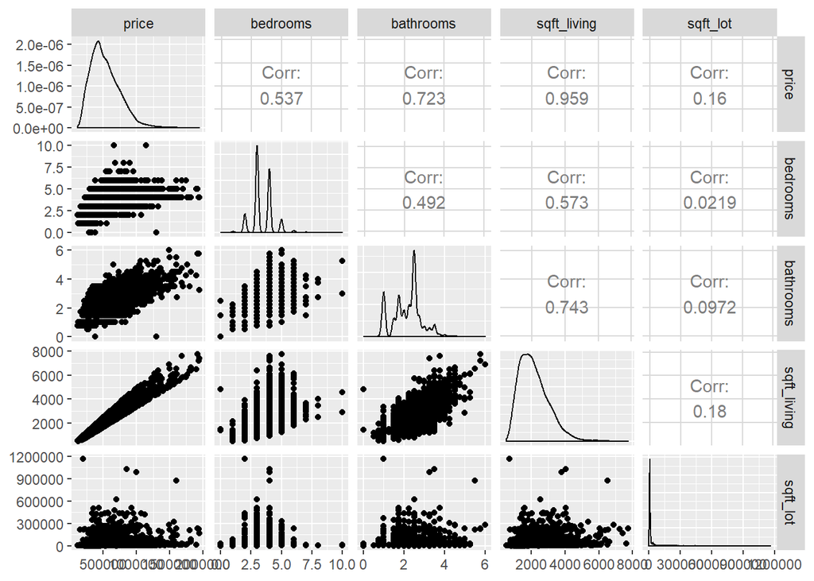

```r
library(ggplot2)

casas <- read.csv('kc_house_data.csv', header = T, na.strings = '?')
ggpairs(casas, columns = 3:7)
```

# Limpieza y transformación de los datos

A continuación utilizando el dataset de venta de casas veremos algunas funcionalidades de R para la transformación de datos.

### Detección de valores faltantes y transformaciones

La función `is.na` nos permite detectar los valores faltantes en un dataset.

El siguiente código muestra el número de elementos faltantes en todo un dataset

`sum(is.na(dataset))`

También podemos buscar valores faltantes en columnas especificas

`sum(is.na(dataset$columna))`

R posee funciones para modificar dataframes las cuales podemos aprovechar para el tratamiento de valores faltantes y transformaciones

Podemos asignar valores nuevos a toda una columna.

`dataframe$columna <- 0`

`dataframe$columna <- funcion(dataframe$columna)`

O podemos hacerlo solo en los campos faltantes.

`dataframe$columna[is.na(dataframe$columna)] <- 0`

`dataframe$columna[is.na(dataframe$columna)] <- funcion(dataframe$columna)`

# Ejercicios sobre transformaciones

### 1. Correción de valores inconsistentes

```r
casas$bathrooms[1:10]
```

```
##  [1] 2.25 1.00 4.50 1.50 1.00 1.75 2.00 3.00 2.00 1.75
```

Como podemos observar la columna bathrooms posee valores inconsistentes ya que no tiene sentido que una casa tenga 4.5 baños.

Modifique la columna bathrooms para que solo posea valores enteros

```r
casas_bathrooms <- casas$bathrooms
casas$bathrooms <- floor(casas$bathrooms)
casas$bathrooms
```

```
##    [1] 2 1 4 1 1 1 2 3 2 1 1 1 2 2 1 1 2 2 2 2 1 1 1 3 3 1 1 2 1 3 2 2 4 1
##   [35] 1 2 1 1 2 2 1 1 2 1 2 1 2 2 1 2 2 2 1 2 2 2 1 1 2 2 2 1 1 2 2 1 2 2
##   [69] 2 1 3 2 3 2 2 1 2 2 2 1 1 2 0 3 2 2 2 2 2 2 2 1 4 1 3 1 1 2 1 1 2 2
##  [103] 1 4 2 2 2 1 2 2 1 2 2 2 2 2 2 2 2 2 3 1 2 1 1 1 2 2 2 2 2 2 2 2 2 2
##  [137] 1 2 3 2 3 2 1 2 2 2 2 1 2 3 2 2 1 4 2 2 3 2 2 1 1 1 1 2 2 2 1 2 2 1
##  [171] 4 2 3 2 2 2 2 1 3 3 3 2 2 1 2 2 2 2 2 1 3 1 1 3 1 1 3 1 2 5 1 1 3 2
##  [205] 1 2 2 2 1 2 1 3 2 2 1 4 2 1 2 2 2 1 2 2 1 2 2 2 2 2 2 1 1 2 2 1 1 2
##  [239] 2 3 1 2 2 1 1 1 1 2 1 2 2 1 2 1 1 3 1 2 1 1 2 2 1 2 1 1 1 2 1 2 2 2
##  [273] 1 1 2 1 2 2 1 1 2 1 1 2 3 2 2 2 1 2 2 2 1 1 1 2 2 2 1 1 2 2 3 2 2 1
##  [307] 2 2 2 1 2 2 1 2 2 1 1 1 2 2 1 1 3 2 2 1 2 2 1 1 2 2 2 2 2 1 3 1 2 2
##  [341] 2 2 1 3 2 2 2 1 1 1 2 2 2 1 1 2 3 3 2 2 3 1 2 2 1 2 1 1 1 2 2 1 3 2
##  [375] 1 2 2 2 1 2 2 2 1 1 2 1 2 2 1 1 2 2 3 1 2 2 2 1 2 2 3 2 2 2 1 3 2 1
##  [409] 2 2 1 3 2 2 2 2 1 1 1 2 1 1 1 4 2 2 2 1 3 1 1 4 1 4 1 2 2 2 2 2 2 2
##  [443] 2 2 1 4 2 2 2 2 2 3 1 1 1 2 1 2 2 2 2 2 1 2 2 3 2 1 1 2 2 1 2 2 2 1
##  [477] 1 1 2 2 2 4 2 2 2 2 2 2 1 2 1 2 1 1 2 1 1 1 2 2 1 2 2 1 2 2 2 1 2 3
```

[output cut: 229 more lines]

### 2. Llevar los datos a distribución normal.

Modifique la columna price del dataset de precios de casas para que siga una distribución normal. Pista: utilice la función `log10`

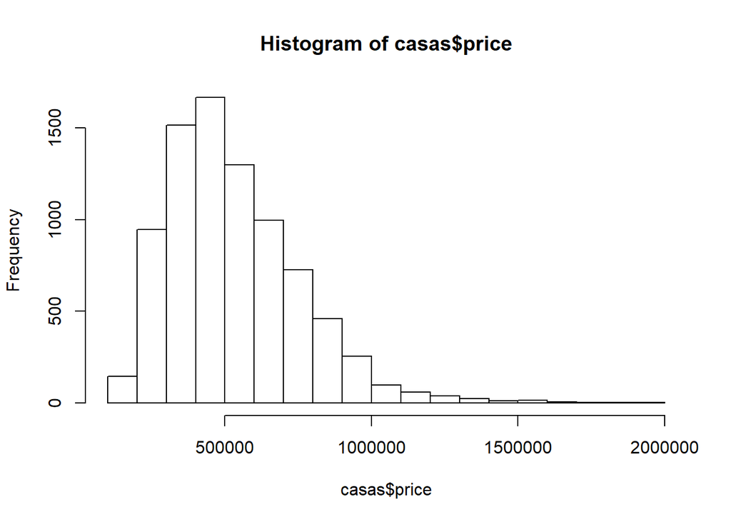

```r
# Precios antes de la modificación
hist(casas$price)
```

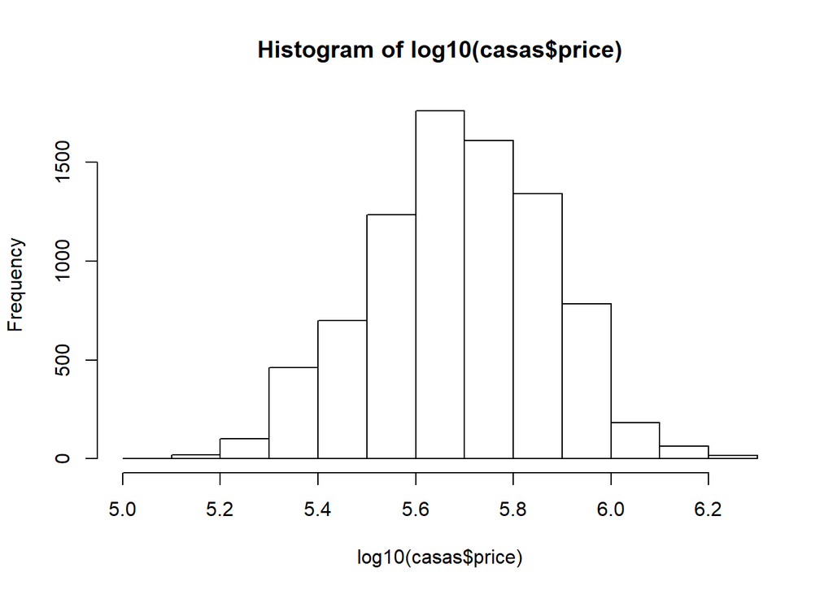

```r
# Escriba su codigo aqui
hist(log10(casas$price))
```

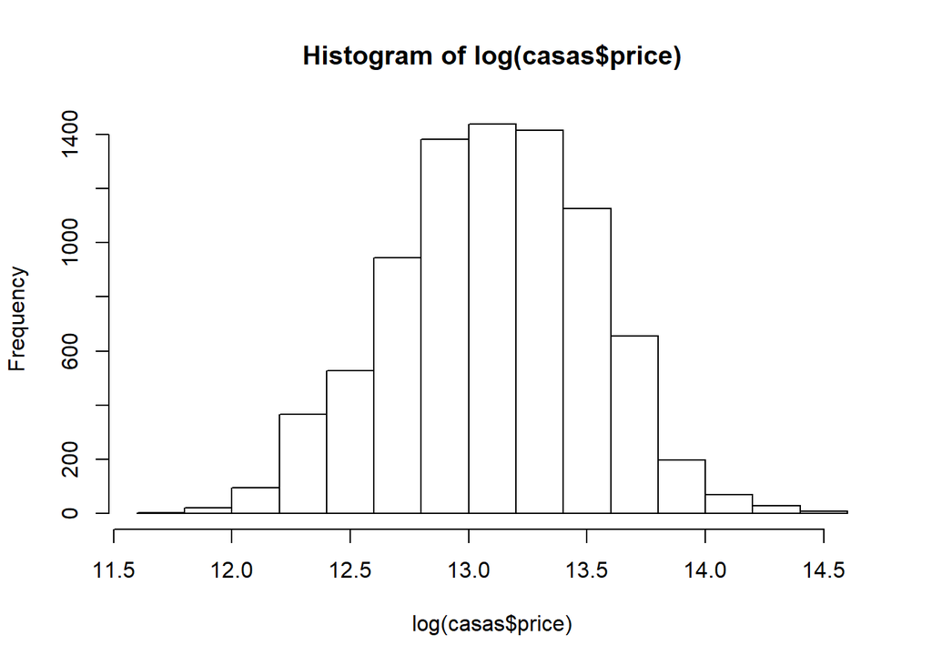

```r
hist(log(casas$price))
```

```r
# Precios normalmente distribuidos
```

Note que ahora los precios ya no se agrupan a la izquierda.

### 3. Imputar datos faltantes

Reemplace los valores faltantes de la columna sqft_living con la mediana de los valores de esa columna. Pista use la función `median`.

Nota: este dataset no posee valores faltantes pero para efectos del ejercicio esto no nos afecta ya que el código sería igual.

```r
casas_sqft_living <- casas$sqft_living
casas$sqft_living[is.na(casas$sqft_living)] <- median(casas$sqft_living)
casas$sqft_living
```

```
##    [1] 2570  770 5420 1060 1430 1370 1810 2950 1890 1620 1070 1520 2570
##   [14] 2320 1190 2330 2360 2620 2570 3595 1280  990 1980 3250 1850 1260
##   [27] 2519 1660 1000 4770 1260 2750 3430 1760 1410 3450 1680 1580 3300
##   [40] 1980 1210 1670 3140 2030 2310  880 2400 1450 2100 2910 2100 2070
##   [53] 1060 2010 2030 3670 1250 1780 3400 1910 2020 1580 1340 2680 1370
##   [66] 1340 3880 2590 1970 1350 2440 3130 4090 1900 2230 1060 1970 2150
##   [79] 1910 1350  860 2440  900 2300 1550 2240 1720 3900 2760 2330 2280
##   [92] 1000 3760 1970 3830  830  720 1510 1400 1230 2460 2100 1120 5310
##  [105] 3820 2210 3500 1670 2900 1890 2950 1970 3360 1320 1940 2180 3320
##  [118] 1930 3150 2030 3040 1275 2580 1000 1070 1750 2440 1640 2110 3040
##  [131] 1840 2990 3520 2180 1450 3230 1640 2020 4040 2550 4800 1410 1550
##  [144] 1980 1600 3300 3840 1220 1750 2840 2990 2000 2085 6070 2250 1440
##  [157] 4040 2450 3130 2120 1250  940 1920 3545 2340 2590 1220 2360 2260
##  [170] 1240 3840 4110 4190 3390 1890 1610 2910 1700 2990 4860 4860  890
##  [183] 2810 1580 1680 2820 1510 2120 3180 2430 4410 1330 1100 3180 1190
```

[output cut: 622 more lines]

### 4. Escalado

Un proceso común en esta etapa es escalar los atributos para que los valores queden en el rango de 0-1.

La siguiente función realiza el escalado de valores

```r
feature_scaling <- function(x) {
  x_escalado <- ((x - min(x)) / (max(x) - min(x)))
  return(x_escalado)
}
```

1. Utilice la función `feature_scaling` para escalar los valores de la columna sqft_lot
2. Compare el resultado con la función `scale()`

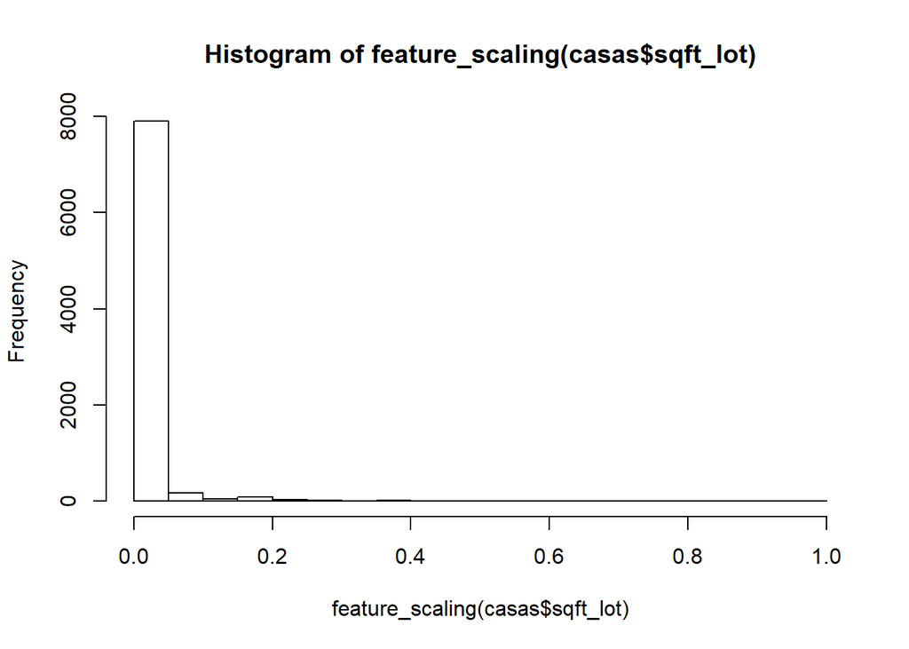

```r
hist(feature_scaling(casas$sqft_lot))
```

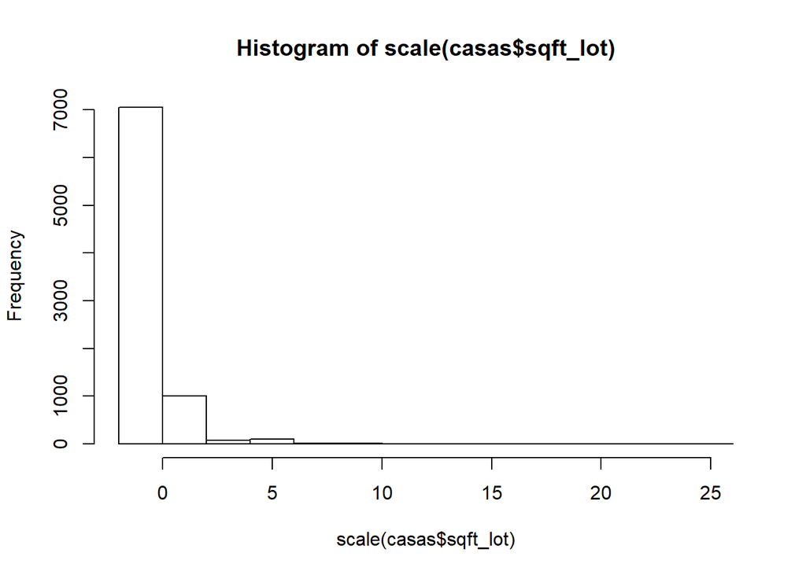

```r
hist(scale(casas$sqft_lot))
```

```r
# En el primer histograma podemos ver como los datos se agrupan de mayormente en 0, mientras que en el segundo si bien hay una tendencia a -1 todavia hay otros datos relevantes en 0.
```

### 5. Normalización con la función z-score

Otra función utilizada para transformar atributos se llama z-score y consiste en restar la media de los datos y dividir por la desviación estandar.

Escriba la función z_score y utilicela sobre la columna bathrooms.

Pista: utilice las funciones `mean`, `sd`

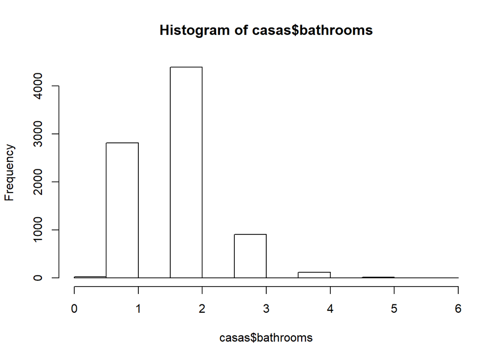

```r
# Datos antes de la transformación
hist(casas$bathrooms)
```

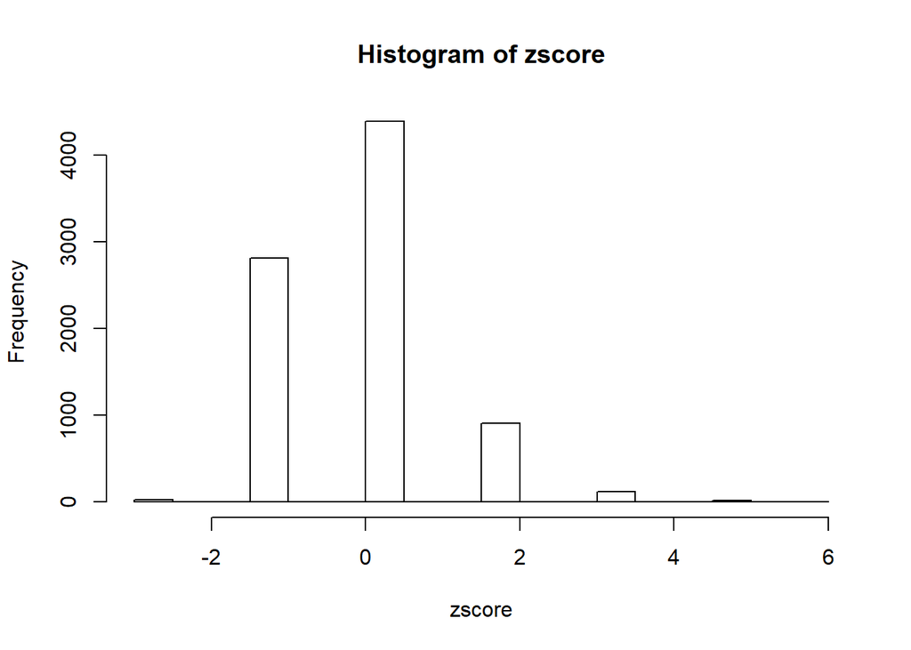

```r
# Escriba su código aqui
z_score <- function(x) {
  return ((x - mean(x)) / sd(x))
}
zscore <- z_score(casas$bathrooms)
# Después de la transformación
hist(zscore)
```

Note que ahora la media de los datos se acerca a 0